# EAE

Anna L Tyler, modified by LAD

September 16, 2025

## Introduction

The purpose of this workflow is to start getting into data sent by Dimitry Krementsov and his graduate student Emily Nelson at UVM as well as add on data involving Lauren Downs.

They are interested in the genetics of multiple sclerosis (MS). The mouse model of MS is called [experimental autoimmune enchephalomyelitis (EAE)](https://www.ncbi.nlm.nih.gov/pmc/articles/PMC3229753/). In this model, mice are injected with CNS antigens which cause development of autoimmunity.

The Krementsov lab is inducing EAE in a panel of CC mice to investigate the effect of genetic backgroud on this model. So far they have identified multiple types of EAE that mirror the human experience better than the standard model. Whereas the classic mouse model displays a progressive form of ascending paralysis, the diverse model has relapsing remitting patterns of disease, as well as axial-rotory (AR) EAE. These patterns are also seen in humans, but the genetics of the heterogeneity of MS in humans has not been well studied.

In this study, we will try to map genetic variants that are associated with subtypes of EAE. We will also use TRiAGE to prioritize genes within the mapped loci. Additionally, data was added to this script so that weight loss and histopathology could be evaluated for genetic underpinnings.

## Collecting and Processing Data

From the Excel file that Emily sent, I saved the CDS_Individuals tab as a csv file. I copied and pasted the body of the data table into a new excel file and saved it as a csv file. I then programatically deleted the empty row separating the founders and the CC lines and removed all slashes from strain names so that “C57BL/6” and “C57BL6” match.

For the additional data, a column in the CDS .csv file was added for average weight loss. (This is for September 2025 only)

Any code that was edited or made with ChatGPT will be noted within in-line comments.

```r
rm(list = ls())

#===============================================================
#I'm hard-coding final parameters for now
#===============================================================
#args <- commandArgs(trailingOnly=T)
#b6_correction <- as.logical(args[1]) #Use B6 score to do batch correction
#batch_as_covar <- as.logical(args[2]) #use batch as a covariate
#rank_norm <- as.logical(args[3]) #whether to rank Z normalize adjusted scores.
#===============================================================



#===============================================================
#hard code the final decisions on corrections and normalizations
#set final_param to FALSE to use the arguments again
#===============================================================
final_param = TRUE

if(final_param){
    b6_correction <- FALSE
    batch_as_covar <- TRUE
    rank_norm <- TRUE
}
#===============================================================

genotypes <- c("MRCA", "sequenced")
genotypes <- genotypes[2]

if(is.na(b6_correction) || length(b6_correction) == 0){
b6_correction = FALSE; batch_as_covar = FALSE; rank_norm = FALSE
}

if(b6_correction && batch_as_covar){stop("Set either b6_correction or batch_as_covar to TRUE, not both.")}

alpha <- c(0.15, 0.2)
```

```r
library(here)
```

```r
all.fun <- list.files(here("Code"), full.names = TRUE, pattern = ".R")
for(i in 1:length(all.fun)){source(all.fun[i])}

overwrite_previous <- TRUE
add_founder_genotypes <- FALSE

#strains identified by remove_strains are excluded from all
#manipulations including normalization and batch corrections.
#justficiations are as follows:
#CC027 - all but 2 were homozygous for the wrong genotype at the H2 locus
#NOD and 129 - are not used for mapping, and were not included in all
#batches, so we cannot use them for normalization
#remove_strains <- NULL
remove_strains <- c("CC027", "NOD", "129")
#remove_strains <- c("CC051", "CC059") #closely related
#remove_strains <- c("CC051") #pick one of them to keep

cc.color.scheme = "original"
#cc.color.scheme = "new"

exclude.zeros = FALSE #if true, we exclude animals with a CDS of 0
disease.thresh = 0 #maximum disease score considered disease-free

cds.file.date = "September_2025" #date for CDS csv file to use in format month_year
histopath.file.date = "September_2025" #date for CDS csv file to use in format month_year

nperm = 1000

if(nperm > 0){
    run_permutations <- TRUE
}else{
    run_permutations <- FALSE
}
```

## Parameters

```r
if(add_founder_genotypes){
    founders.included = "yes"
}else{
    founders.included = "no"
}

if(length(remove_strains) > 0){
    strains.removed <- paste(remove_strains, collapse = ", ")
}else{
    strains.removed = "none"
}

if(!exclude.zeros){
    zero.text <- "Zeros are included in CDS"
    zero.treatment <- "included with"
}else{
    zero.text <- paste("Animals with scores of", disease.thresh, "and below are excluded from CDS.")
    zero.treatment <- "excluded from"
}

if(b6_correction){
    correction.text <- "Batch corrections were made using B6 CDS."
    correction.label <- "B6-batch"
}
if(batch_as_covar){
    correction.text <- "Batch corrections were done using batch as a covariate."
    correction.label <- "covar-batch"
}
if(!b6_correction && !batch_as_covar){
    correction.text <- "No batch corrections were done."
    correction.label <- "no-batch"
}

if(rank_norm){
    norm.text <- "Rank Z normalization was performed."
    norm.label <- "rank-norm"
}else{
    norm.text <- "Rank Z normalization was not performed."
    norm.label <- "no-norm"
}

file.label <- paste(correction.label, norm.label, genotypes, sep = "_")
```

The parameters for this run are as follows:

- Genotypes used: sequenced
- Founders included: no
- CC Strains removed: CC027, NOD, 129
- Treatment of zeros: Zeros are included in CDS
- Batch correction: Batch corrections were done using batch as a covariate.
- Normalization: Rank Z normalization was performed.

```r
results.dir <- here("Results", paste("Zeros", strsplit(zero.treatment, " ")[[1]][1], file.label, sep = "_"))
if(!file.exists(results.dir)){dir.create(results.dir)}
```

```r
all.packages <- c("pheatmap", "qtl2", "ggplot2", "abind", "igraph", "knitr", "parallel",
    "stringr", "grid")
load_libraries(all.packages)
cores = NULL #detectCores()-1
```

Read in phenotype data.

```r
if(cc.color.scheme == "original"){
    strain.colors <- CCorigcolors
}else{
    strain.colors <- CCcolors
}

cds <- read.csv(here("Data", paste0("CDS_", cds.file.date, ".csv")), strip.white = TRUE)
histopath <- read.csv(here("Data", paste0("histopath_", histopath.file.date, ".csv")), strip.white = TRUE)

#take out any slashes in strain names in cds
cds[,"Strain"]  <- gsub("/", "", cds[,"Strain"], fixed = TRUE)
```

This run uses the CDS file from September 2025.

## Remove excluded strains

If any strains need to be removed from the analysis, do that now before any numbers are manipulated.

```r
#remove any empty rows that were inserted to visually separate
#the founders from the rest of the strains
cds.data.idx <- which(!is.na(cds[,"ID"]))
cds <- cds[cds.data.idx,]


#remove specified strains from cds
if(length(remove_strains) != 0){
    remove.cds <- unlist(sapply(remove_strains, function(x) which(cds[,"Strain"] == x)))
    cds <- cds[-remove.cds,]
}
```

```r
num.cds <- as.matrix(sapply(cds[,c("Classical.CDS", "AR.CDS", "Global.CDS", "Avg.Weight.Loss")], as.numeric)) #had to change this with Chat to make the values numeric
rownames(num.cds) <- cds[,"ID"]
#set all scores equal to or lower than the disease threshold
#to zero
if(exclude.zeros){
    num.cds[which(num.cds <= disease.thresh)] <- 0
}

factor.cds <- as.matrix(cds[,c("Strain", "Sex")])
u_batch <- unique(cds[,"EXP"])

#remove animals in batch 170 - these were validation, not part of the original experiment
to.remove = "X170"
keep.batch <- which(u_batch != "X170")
u_batch <- u_batch[keep.batch]

keep.idx <- which(cds[,"EXP"] != "X170")
cds <- cds[keep.idx,]
num.cds <- num.cds[keep.idx,]
factor.cds <- factor.cds[keep.idx,]

batch.mat <- matrix(0, nrow = nrow(cds), ncol = length(u_batch))
colnames(batch.mat) <- u_batch
for(b in 1:ncol(batch.mat)){
    batch.mat[which(cds[,"EXP"] == u_batch[b]),b] <- 1
}
cds.covar <- as.matrix(cbind(batch.mat, cds[,"Age.at.D0",drop=FALSE]))

pheno.strains <- cds[,"Strain"]
eae.strains <- unique(pheno.strains)
```

## Samples by strain

The following heatmap shows how many individuals are in each strain by sex combination.

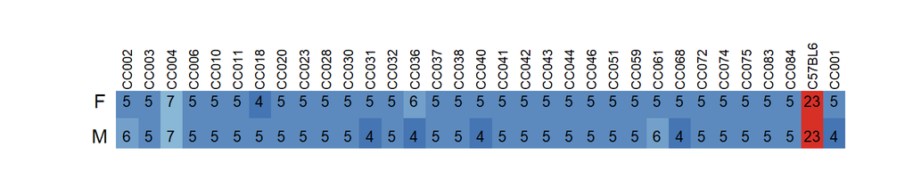

```r
count.table <- table(cds[,c("Sex", "Strain")])
strain.order <- c(3:ncol(count.table), 1,2)
par(mar = c(1,4,4,2))
imageWithText(count.table[,strain.order], use.pheatmap.colors = TRUE,
    col.text.shift = -1.4, row.text.shift = -2, col.text.adj = 0,
    col.text.cex = 0.7, cex = 0.8, row.text.adj = 0.5)
```

## CDS Distribution

Each day of the study, each mouse is given a disease CDS score between 0 and 5, with lower numbers indicating less disease. The cumulative disease score (CDS) for a given mouse is the sum of these scores over the course of the study.

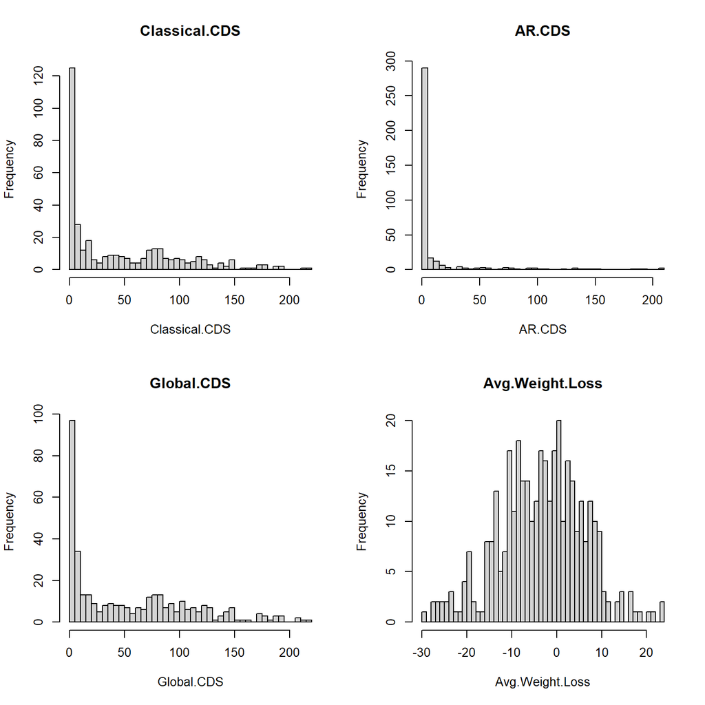

```r
par(mfrow = c(2,2))
for(i in 1:ncol(num.cds)){
    hist(num.cds[,i], breaks = 50, main = colnames(num.cds)[i],
    xlab = colnames(num.cds)[i])
}
```

There are many mice that never display measurable symptoms and have cumulative disease scores of 0. This kind of floor effect causes problems with statistical tests that assume a normal distribution.

If exclude.zeros is set to TRUE, these 0 values will be excluded from CDS mapping.

In this analysis Zeros are included in CDS.

The plots below show the CDS distribution by strain.

```r
plot_cds_by_strain <- function(scores, strain.labels, exclude.zeros = TRUE,
    ymin = NULL, ymax = NULL, plot.label = ""){

    u_strain <- unique(strain.labels)
    strain.idx <- lapply(u_strain, function(x) which(strain.labels == x))

    if(exclude.zeros){
        nonzero.idx <- which(scores != 0)
    }else{
        nonzero.idx <- 1:length(scores)
    }
    strain.cds <- lapply(strain.idx, function(x) scores[intersect(nonzero.idx, x)])
    names(strain.cds) <- u_strain
    strain.order <- order(sapply(strain.cds, mean))

    if(is.null(ymax)){ymax = max(scores, na.rm = TRUE)}
    if(is.null(ymin)){
        ymin = min(scores, na.rm = TRUE)
        #if(ymin > 0){ymin <- 0}
    }

    #quartz(width = 10, height = 5)
    layout(matrix(c(1,2), ncol = 2), width = c(1, 0.5))
    par(mar = c(4,4,4,0))
    stripchart(strain.cds[strain.order], vertical = TRUE, pch = 16,
        col = "gray", method = "jitter", las = 2, ylim = c(ymin, ymax),
        main = paste(plot.label), ylab = paste(plot.label, "values"))
    a <- hist(unlist(strain.cds), plot = FALSE)
    par(mar = c(4,0,4,2))
    plot.new()
    plot.window(xlim = c(0, max(a$counts)), ylim = c(ymin, ymax))
    segments(x0 = rep(0, length(a$counts)), x1 = a$counts, y0 = a$mids,
        lwd = 10, col = "gray")
    #text(x = a$counts+2, y = a$mids, labels = a$counts, adj = 0, cex = 0.7)
    mtext("Individual Counts", side = 3)
    axis(1)

    invisible(strain.cds)
}

for(cd in 1:ncol(num.cds)){
    cat("###", colnames(num.cds)[cd], "\n")
    temp.vals <- plot_cds_by_strain(scores = num.cds[,cd],
        strain.labels = factor.cds[,"Strain"], exclude.zeros = exclude.zeros,
        ymax = max(num.cds[,1:3]), plot.label = colnames(num.cds)[cd]) # didn't like max() for all of them so using Chat for syntax reset it to max the former 3 columns
    cat("\n\n")
}
```

### Classical.CDS

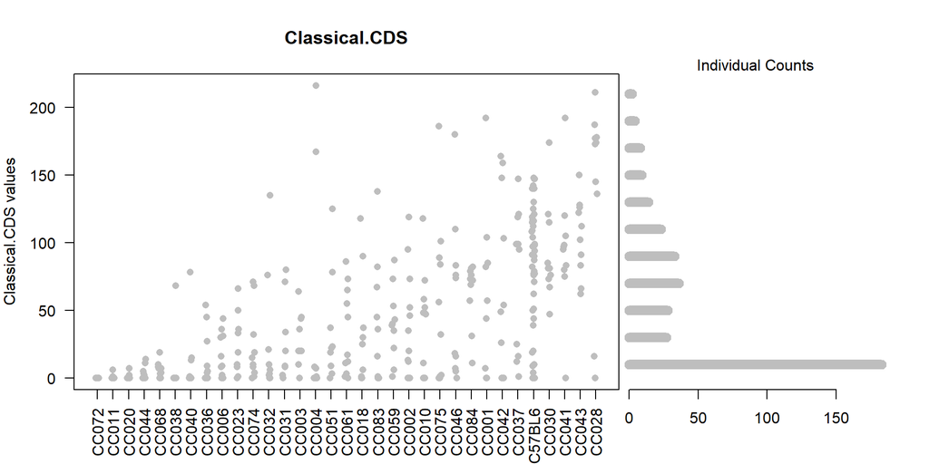

### AR.CDS

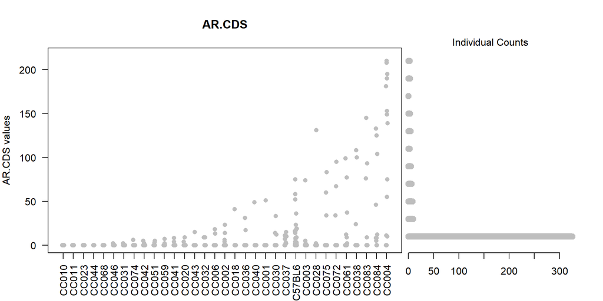

### Global.CDS

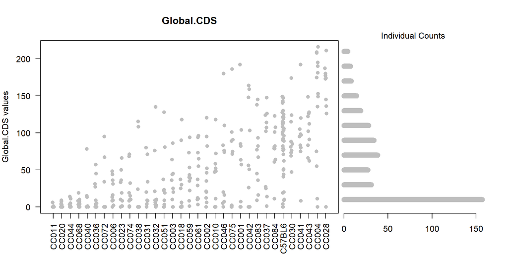

### Avg.Weight.Loss

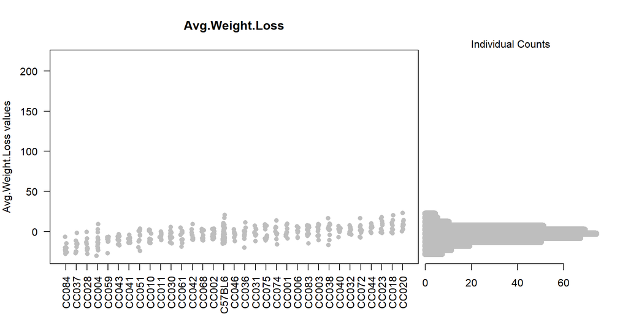

## Batch Effects

The individuals were run in multiple batches, which can cause systematic biases in the data. We need to correct any batch effects that we find before we map.

The following heatmap shows how the different strains and sexes were represented in different batches. The males and females are shown separately.

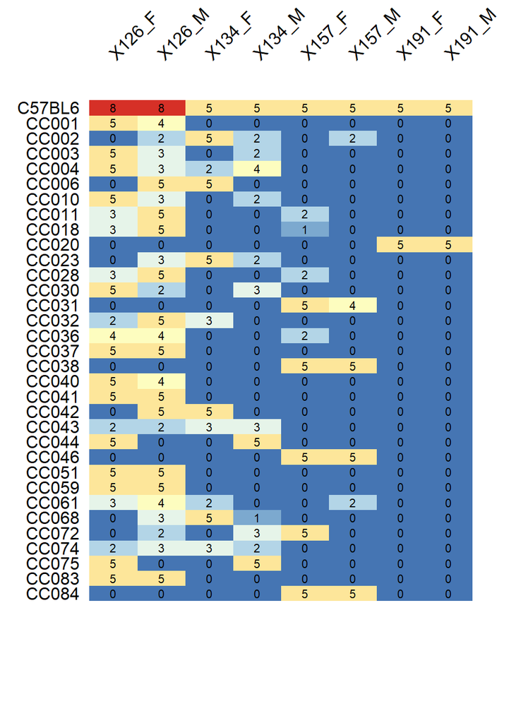

```r
batch.list <- vector(mode = "list", length = length(u_batch))
for(b in 1:length(u_batch)){
    batch.idx <- which(cds.covar[,b] == 1)
    batch.mat <- matrix(0, nrow = length(eae.strains), ncol = 2)
    rownames(batch.mat) <- eae.strains
    batch.table <- table(data.frame(factor.cds[batch.idx,]))
    batch.mat[match(rownames(batch.table), eae.strains),] <- batch.table
    colnames(batch.mat) <- paste(colnames(cds.covar)[b], colnames(batch.table), sep = "_")
    batch.list[[b]] <- batch.mat
}
all.batch.counts <- Reduce("cbind", batch.list)
imageWithText(all.batch.counts, use.pheatmap.colors = TRUE, col.text.shift = -38.5,
col.text.rotation = 45, col.text.adj = 0, cex = 0.7)
```

```r
b6.idx <- which(factor.cds[,1] == "C57BL6")
if(exclude.zeros){
    nonzero.idx <- lapply(1:ncol(num.cds), function(x) which(num.cds[,x] != 0))
}else{
    nonzero.idx <- lapply(1:ncol(num.cds), function(x) 1:nrow(num.cds))
}
b6.batch.idx <- apply(cds.covar[,1:(ncol(cds.covar)-1)], 2,
    function(x) intersect(which(x == 1), b6.idx))

par(mfrow = c(2,2))
b6.by.batch <- vector(mode = "list", length = ncol(num.cds))
names(b6.by.batch) <- colnames(num.cds)
for(cd in 1:ncol(num.cds)){
    #get batch values for this CDS
    vals.by.batch <- lapply(1:length(b6.batch.idx),
        function(x) num.cds[intersect(b6.batch.idx[[x]], nonzero.idx[[cd]]),cd])
    names(vals.by.batch) <- u_batch
    b6.by.batch[[cd]] <- vals.by.batch
    boxplot(b6.by.batch[[cd]], main = colnames(num.cds)[cd])
}
```

[output not shown]

### Batch correction procedure

The B6 batch correction procedure is as follows:

1. Calculate the overall mean CDS for B6 mice across the entire experiment
2. Calculate the mean CDS B6 mice in each batch.
3. Adjust all mice in each batch based on the difference in means in the B6. Subtract off the mean deviation, and divide by the standard deviation.
4. Male and female B6 mice do not have a sex difference in CDS, and adjusting by the two sexes separately could inadvertently introduce a sex effect into the other strains, so we use overall means rather than sex-specific means.

The batch correction procedure using batch as a covariate is as follows:

1. Create a binary matrix indicating whether each individual was run in each batch (1) or not (0).
2. Regress this matrix out of the CDS matrix.

### Remove batch effects

```r
#choose which phenotypes to batch
#correct using their indices.
cds.idx <- c(1,2,3)
```

```r
adj.cds <- num.cds
```

```r
if(batch_as_covar){
    adj.cds <- adjust(num.cds, cds.covar[,1:ncol(cds.covar)-1])
}
```

```r
if(b6_correction){
    batch.mean <- sapply(b6.by.batch, function(x) sapply(x, mean))
    batch.sd <- sapply(b6.by.batch, function(x) sapply(x, sd))
    batch.sd[which(is.na(batch.sd))] <- 1

    #for each batch
    for(b in c(1:(ncol(cds.covar)-1))){
        batch.idx <- which(cds.covar[,b] == 1)
        for(j in cds.idx){ #only correct classical and global
            if(exclude.zeros){
                    nonzero.idx <- which(num.cds[,j] != 0)
                }else{
                    nonzero.idx <- 1:nrow(num.cds)
                }
            adj.idx <- intersect(batch.idx, nonzero.idx)
            adj.cds[adj.idx,j] <- (num.cds[adj.idx,j] - batch.mean[b,j])/batch.sd[b,j]
        }
    }

}
```

### Age at D0

Another one of our covariates is Age.at.D0.

The following boxplot shows that age varies significantly by batch.

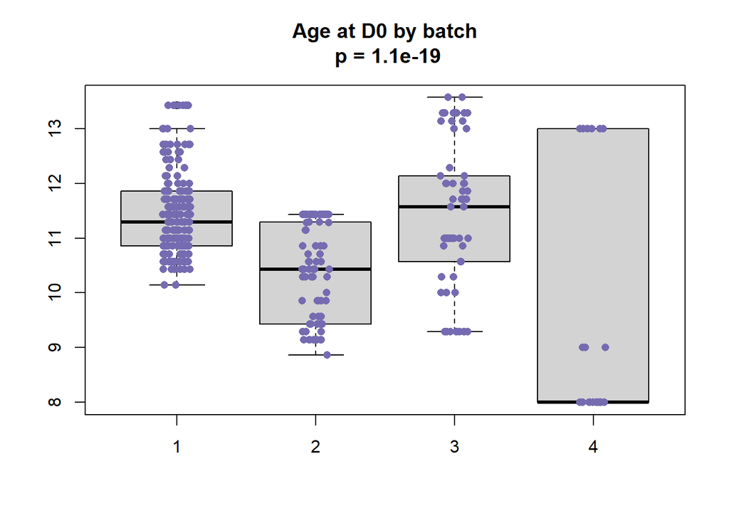

```r
age <- cds.covar[,ncol(cds.covar)]
age.by.batch <- lapply(1:(ncol(cds.covar)-1), function(x) age[which(cds.covar[,x] == 1)])
p.val <- aov.by.list(age.by.batch)$"Pr(>F)"[1]

boxplot(age.by.batch, main = paste("Age at D0 by batch\n", "p =", signif(p.val, 2)))
stripchart(age.by.batch, vertical = TRUE, method = "jitter", pch = 16,
    col = "#756bb1", add = TRUE)
```

The following plots show the relationship between Age.at.D0 and each CDS after adjusting for batch.

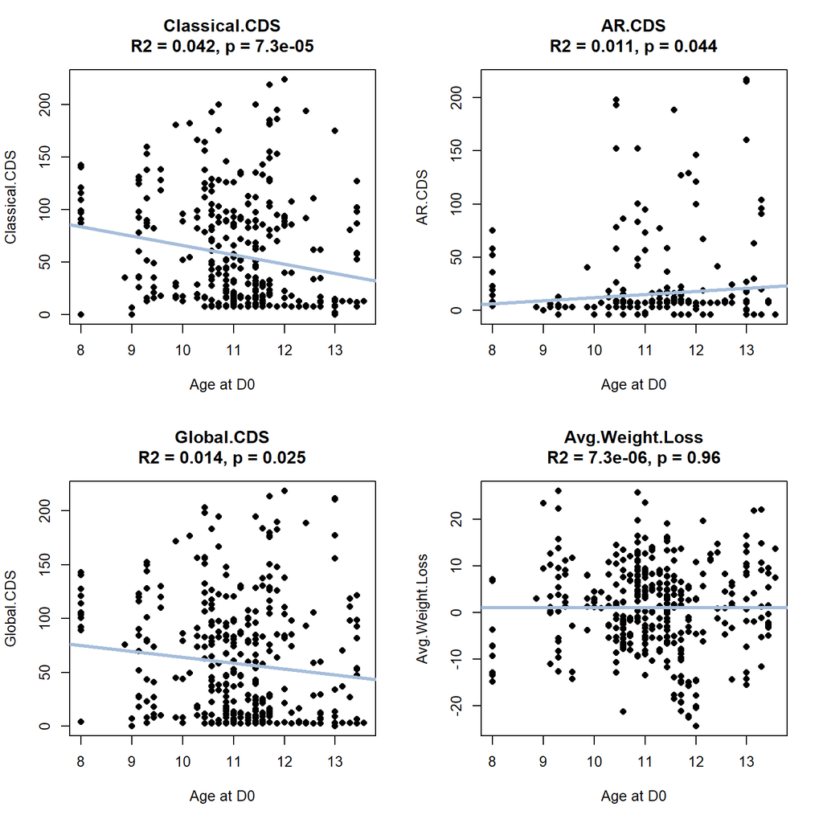

```r
u_age <- unique(cds.covar[,"Age.at.D0"])
age.idx <- lapply(u_age, function(x) which(cds.covar[,"Age.at.D0"] == x))
cds.by.age <- lapply(age.idx, function(x) adj.cds[x,,drop=FALSE])

par(mfrow = c(2,2))
for(i in 1:4){
    just.one <- lapply(cds.by.age, function(x) x[,i])
    x.vals <- lapply(1:length(just.one), function(x) rep(u_age[x], length(just.one[[x]])))
    x <- unlist(x.vals)
    y <- unlist(just.one)
    if(exclude.zeros){
        nonzero.idx <- which(y != 0)
    }else{
        nonzero.idx <- 1:length(y)
    }

    plot.with.model(x[nonzero.idx], y[nonzero.idx], xlab = "Age at D0",
        ylab = colnames(num.cds)[i], main = colnames(num.cds)[i])
}
```

```r
#adjust for age
for(i in 1:ncol(adj.cds)){
    if(exclude.zeros){
        nonzero.idx <- which(num.cds[,i] != 0)
    }else{
        nonzero.idx <- 1:nrow(num.cds)
    }
    adj.cds[nonzero.idx,i] <- adjust(adj.cds[nonzero.idx,i,drop=FALSE],
        cds.covar[nonzero.idx,"Age.at.D0",drop=FALSE])
}
```

```r
#write out the results of whatever adjustments we have done
write.table(adj.cds, file.path(results.dir, "Adj_CDS.csv"), sep = ",", quote = FALSE)
```

Rank Z normalize the CDS scores if this is specified.

```r
norm.cds <- adj.cds
colnames(norm.cds) <- gsub(".CDS", "", colnames(norm.cds)) #take off CDS in labels, to save room in plots
```

```r
if(rank_norm){
    for(i in 1:ncol(norm.cds)){
        if(exclude.zeros){
            nonzero.idx <- which(num.cds[,i] != 0)
        }else{
            nonzero.idx <- 1:nrow(num.cds)
        }
        norm.cds[nonzero.idx,i] <- rankZ(adj.cds[nonzero.idx,i])
    }
}
colnames(norm.cds) <- gsub(".CDS", "", colnames(norm.cds)) #take off CDS, to save room in plots

#write out normzliaed values
write.table(norm.cds, file.path(results.dir, "Norm_CDS.csv"), sep = ",", quote = FALSE)
```

### Normalized Scores

The following plots show the distribution of each disease score after adjustments and normalization.

```r
#ymin = min(norm.cds);ymax = max(norm.cds) #all on same axes
ymin = NULL; ymax = NULL #all on independend axes
for(cd in 1:ncol(norm.cds)){
    cat("####", colnames(norm.cds)[cd], "\n")
    plot_cds_by_strain(scores = norm.cds[,cd],
        strain.labels = factor.cds[,"Strain"], exclude.zeros = exclude.zeros,
        ymin = ymin, ymax = ymax, plot.label = colnames(num.cds)[cd])
    cat("\n\n")
}
```

#### Classical

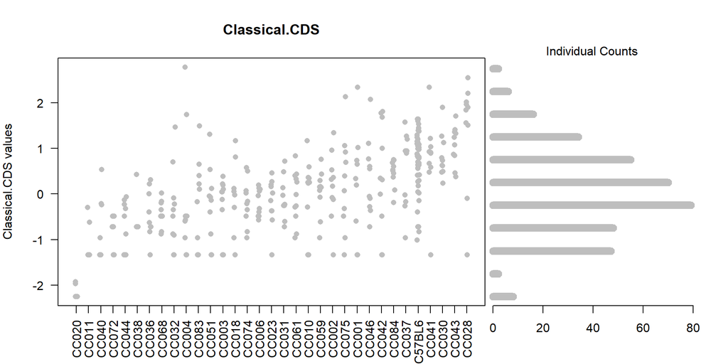

#### AR

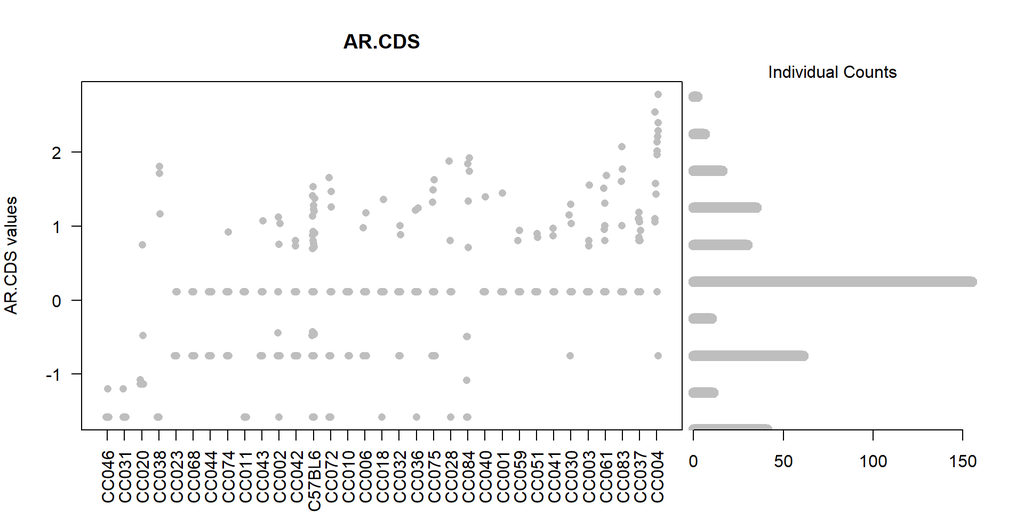

#### Global

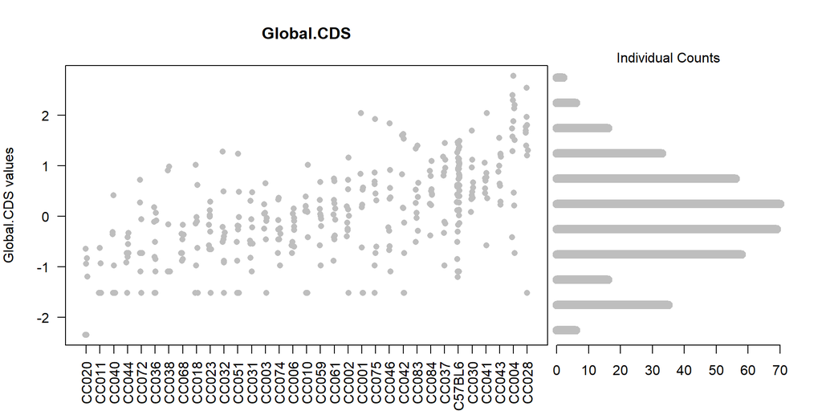

#### Avg.Weight.Loss

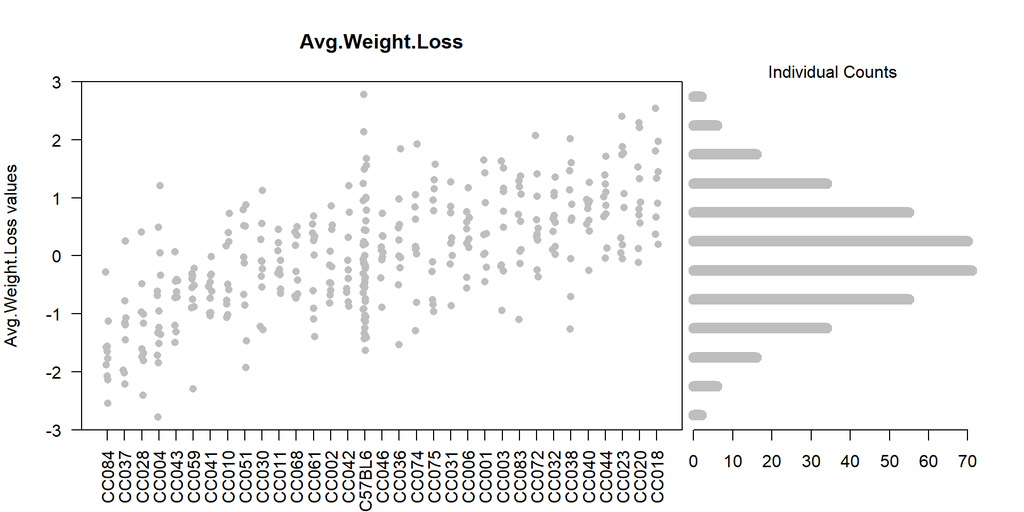

## CC genotypes

I downloaded the CC genotypes from the UNC website: http://csbio.unc.edu/CCstatus/CCGenomes/#genotypes

I downloaded the Most Recent Common Ancestor file. This has marker names from the mega muga. I downloaded the mega muga marker map from the Jackson Laboratory [resource for CC/DO mice](https://www.jax.org/research-and-faculty/genetic-diversity-initiative/tools-data/diversity-outbred-reference-data)

```r
cc.geno <- readRDS(here("Data", "MRCA10_modelprobs_trim.rds"))

if(genotypes == "MRCA"){

    marker.info.file <- here("Data", "mouse", "mm_uwisc_v1.csv")
    marker.info <- read.csv(marker.info.file)

    #convert the map and the genoprobs into a qtl2 object
    cross_obj <- array2qtl2(cc.geno, marker.info, chr = c(1:19, "X"), chr.col = "chr",
        pos.col = "bp_mm10", crosstype = "risib8")

    cc.genoprobs <- cross_obj$genoprobs
    map <- cross_obj$map

    K <- calc_kinship(cc.genoprobs, "loco")
}
```

```r
if(genotypes == "sequenced"){
    map.file <- here("Data", "map.RDS")
    new.geno.file <- here("Data", "genoprobs.RDS")
    k.file <- here("Data", "kinship_loco.RDS")

    if(!file.exists(map.file)){
        file <- paste0("https://raw.githubusercontent.com/rqtl/", "qtl2data/master/CC/cc.zip")
        cc <- read_cross2(file)
        map <- cc$pmap
        saveRDS(map, map.file)

        cc.official <- rownames(cc$geno[[1]])
        cc.alias <- sapply(strsplit(cc.official, "/"), function(x) x[1])
        write.table(cbind(cc.official, cc.alias), here("Data", "CC_names.txt"), sep = "\t",
            quote = FALSE, row.names = FALSE, col.names = FALSE)

        cc.genoprobs <- calc_genoprob(cc, cores = cores)
        new.genoprobs <- cc.genoprobs

        #add strains 83 and 84 to the genoprobs from the MRCA genotypes
        new.strains <- c("CC083", "CC084")
        new.strain.idx <- match(new.strains, rownames(cc.geno))
        for(i in 1:length(cc.genoprobs)){
            chr.markers <- dimnames(cc.genoprobs[[i]])[[3]]
            common.markers <- intersect(chr.markers, dimnames(cc.geno)[[3]])
            orig.idx <- match(common.markers, dimnames(cc.genoprobs[[i]])[[3]])
            new.idx <- match(common.markers, dimnames(cc.geno)[[3]])
            new.chr <- abind(cc.genoprobs[[i]][,,orig.idx], cc.geno[new.strain.idx,,new.idx], along = 1)
            new.genoprobs[[i]] <- new.chr
        }
        saveRDS(new.genoprobs, new.geno.file)

        #overwrite the original objecct
        cc.genoprobs <- new.genoprobs

        K <- calc_kinship(new.genoprobs, "loco")
        saveRDS(K, k.file)
    }else{
        map <- readRDS(map.file)
        cc.genoprobs <- readRDS(new.geno.file)
        K <- readRDS(k.file)
    }
}
```

If specified, add genoptypes for 129, NOD, and B6, so we can use them in mapping.

```r
if(add_founder_genotypes){
    founder_fun <- function(strain.name){
        founder.genotypes <- rep(0, length(strain.colors))
        founder.idx <- which(names(strain.colors) == strain.name)
        founder.genotypes[founder.idx] <- 1
        return(founder.genotypes)
    }

    strain.129 <- founder_fun("129")
    strain.b6 <- founder_fun("B6")
    strain.nod <- founder_fun("NOD")

    mapping.genoprobs  <- cc.genoprobs
    for(i in 1:length(cc.genoprobs)){
        ind.129 <- matrix(strain.129, nrow = ncol(cc.genoprobs[[i]]),
            ncol = dim(cc.genoprobs[[i]])[3])
        ind.b6 <- matrix(strain.b6, nrow = ncol(cc.genoprobs[[i]]),
            ncol = dim(cc.genoprobs[[i]])[3])
        ind.nod <- matrix(strain.nod, nrow = ncol(cc.genoprobs[[i]]),
            ncol = dim(cc.genoprobs[[i]])[3])
        new.chr <- abind(cc.genoprobs[[i]], ind.129, ind.b6, ind.nod, along = 1)
        rownames(new.chr)[tail(1:length(rownames(new.chr)), 3)] <- c("129", "C57BL6", "NOD")
        mapping.genoprobs[[i]] <- new.chr
    }

    #recalculate K for the new genoprobs.
    mapping.K <- calc_kinship(mapping.genoprobs, "loco")
    mapping.strains <- eae.strains
}else{
    mapping.genoprobs <- cc.genoprobs
    mapping.K <- K
    mapping.strains <- eae.strains[grep("CC", eae.strains)]
}
```

## Allele Frequencies

The following plots show the frequencies of each founder allele across each chromosome. Regions in which the allele frequencies are imbalanced may not be good for mapping.

```r
allele_freq <- lapply(mapping.genoprobs, function(x) apply(x, 3, colMeans))
for(ch in 1:length(allele_freq)){
    cat("### Chr", names(map)[[ch]], "\n")
    layout(matrix(c(1,2), nrow = 1), widths = c(1,0.3))
    par(mar = c(4,4,4,0))
    plot.new()
    plot.window(xlim = c(0, max(map[[ch]])), ylim = c(0,0.4))
    for(a in 1:nrow(allele_freq[[ch]])){
        points(map[[ch]][dimnames(mapping.genoprobs[[ch]])[[3]]],
        allele_freq[[ch]][a,], col = strain.colors[a], type = "l", lwd = 2)
    }
    abline(h = 0)
    axis(1)
    axis(2)
    mtext(paste("Chr", names(map)[[ch]]))
    plot.new()
    plot.window(xlim = c(0,1), ylim = c(0,1))
    par(mar = c(4,0,4,0))
    legend(x = 0, y = 1, lty = 1, col = strain.colors, legend = names(strain.colors),
        horiz = FALSE, bg = "white", lwd = 2, adj = 0)
    cat("\n\n")
}
```

### Chr 1

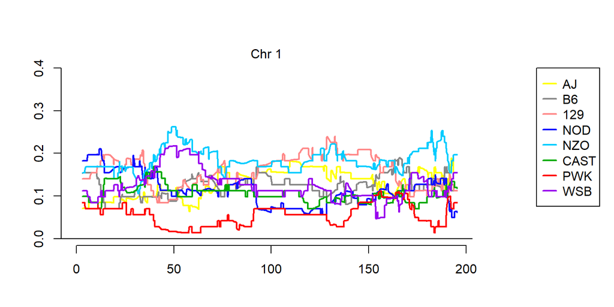

### Chr 2

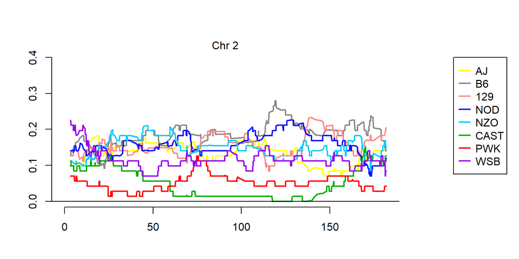

### Chr 3

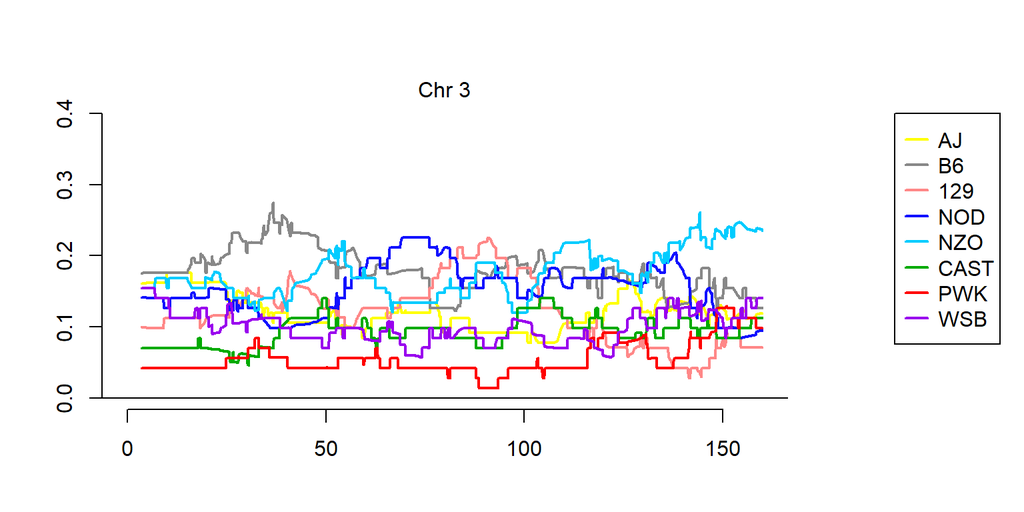

### Chr 4

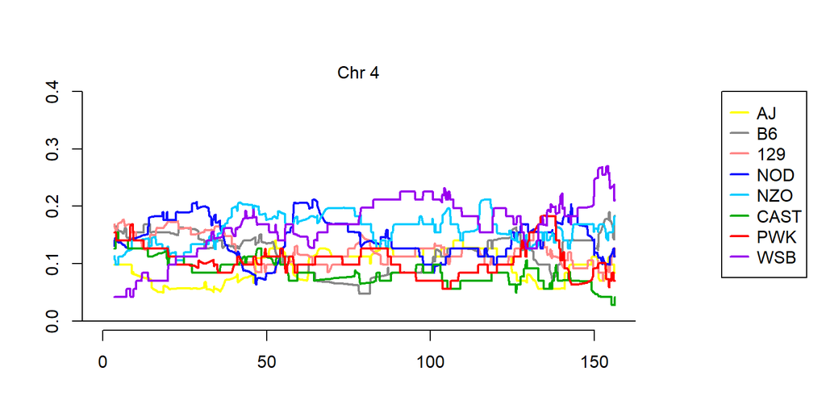

### Chr 5

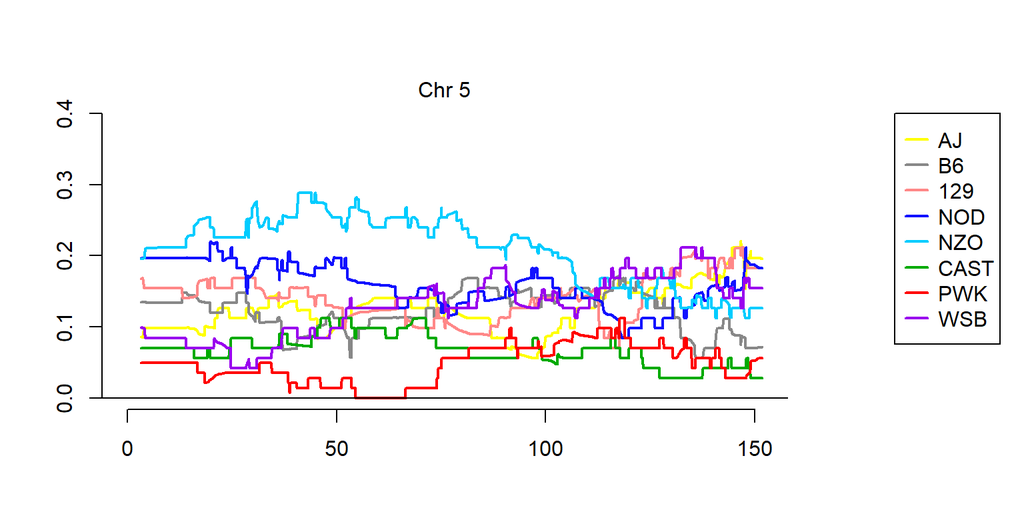

### Chr 6

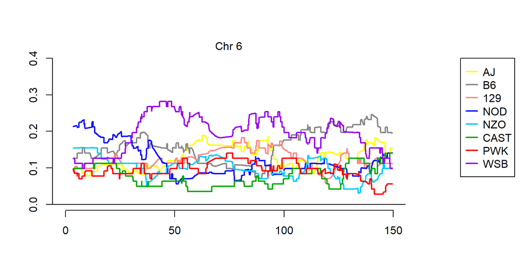

### Chr 7

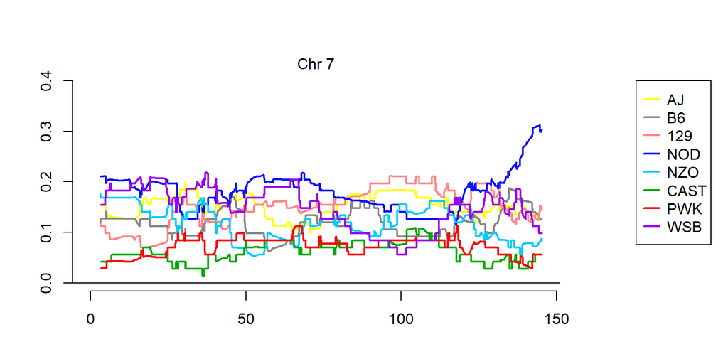

### Chr 8

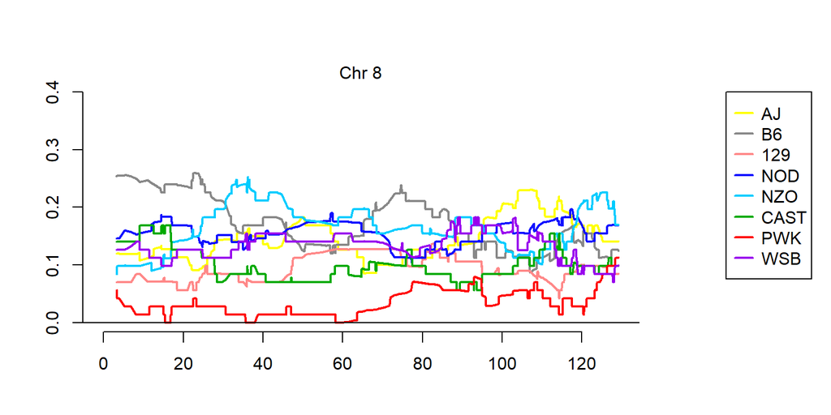

### Chr 9

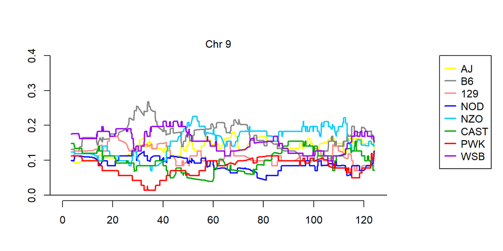

### Chr 10

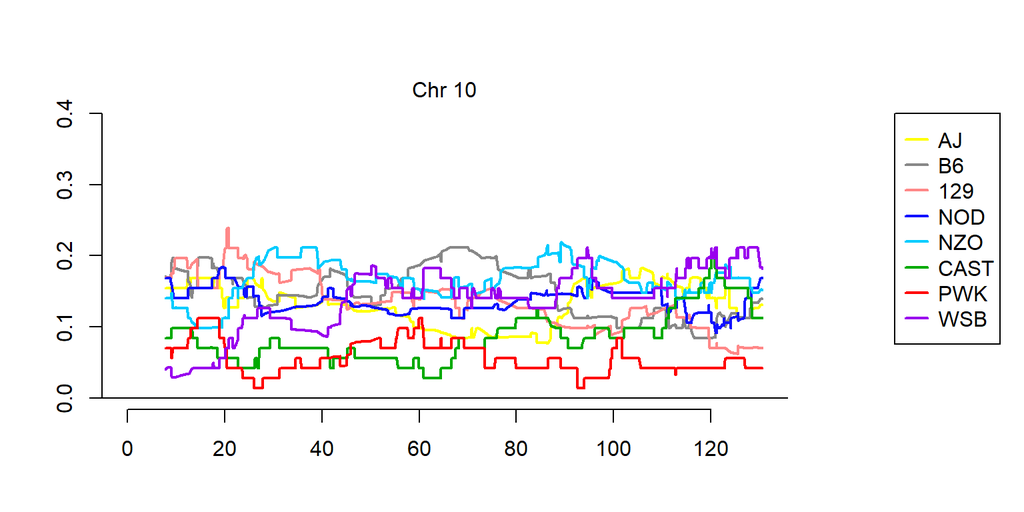

### Chr 11

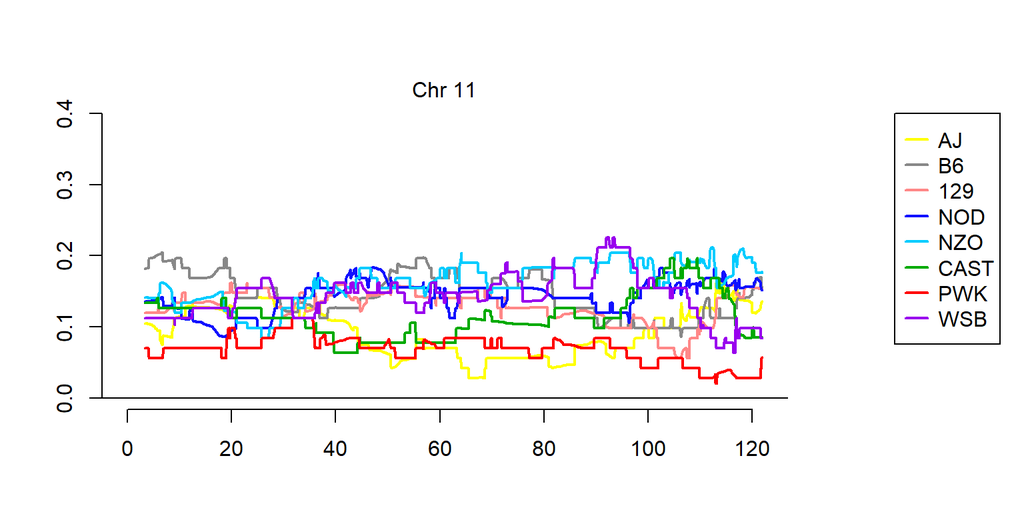

### Chr 12

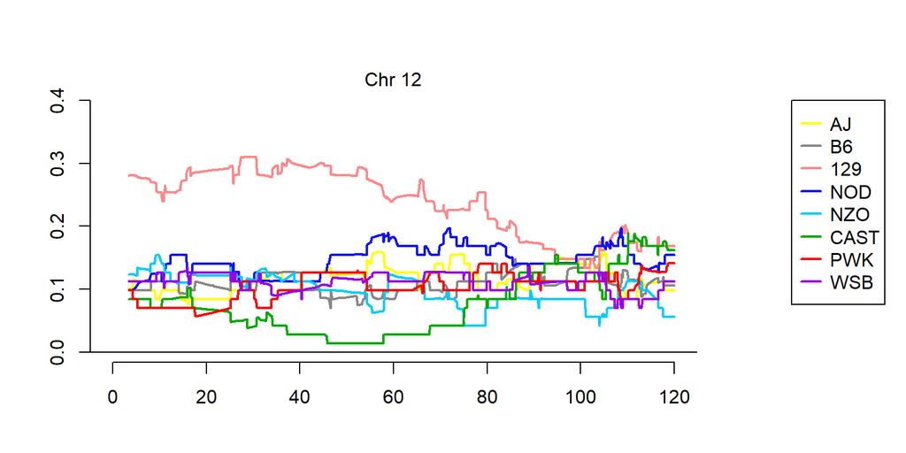

### Chr 13

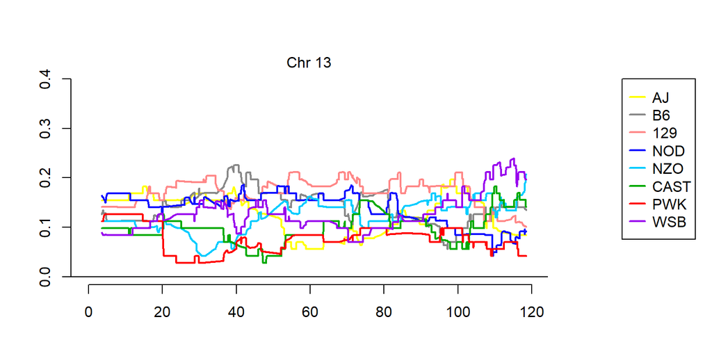

### Chr 14

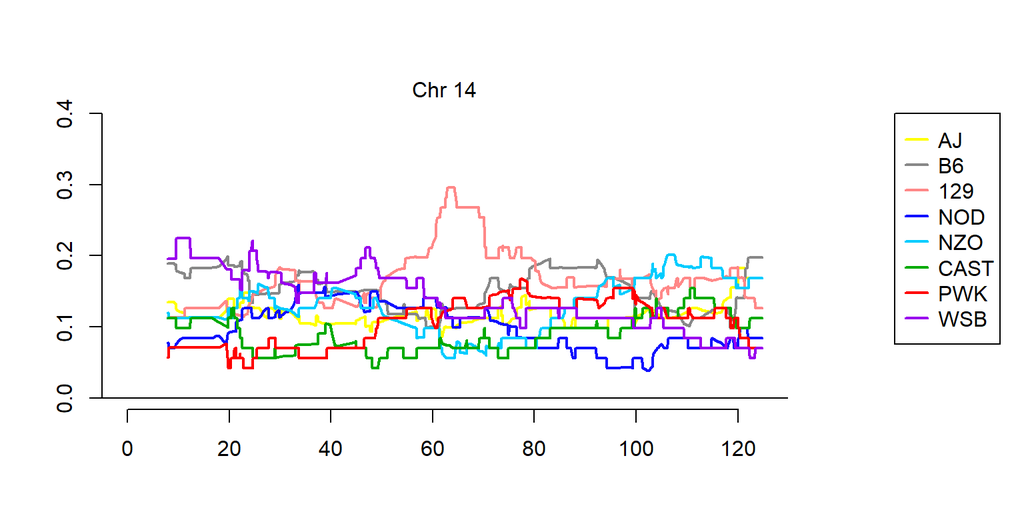

### Chr 15

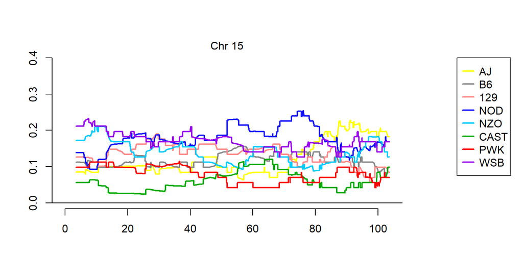

### Chr 16

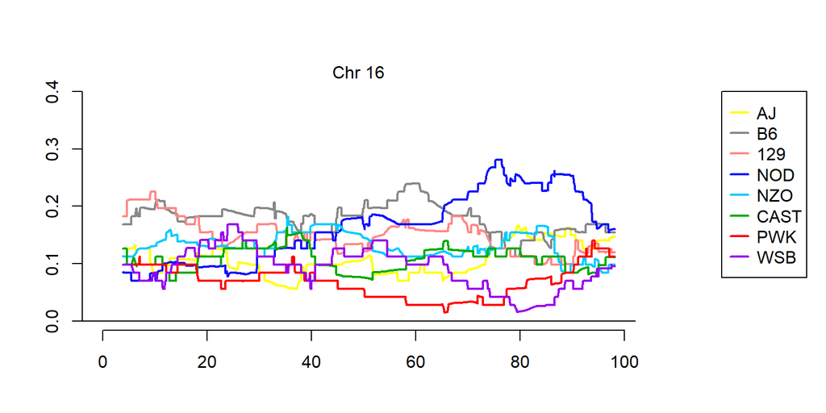

### Chr 17

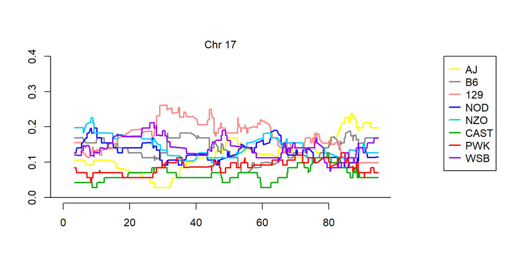